# Forecasting Generation in ERCOT by Fuel Type

Angela Zeng, Kristen Trinh, Eliza Henderson

#### Introduction, Motivation, Relevance, Objectives

This project forecasts ERCOT monthly generation by fuel type to analyze energy transition trends. As a leader in renewable energy generation in the United States, ERCOT serves as an example of how development and adoption may play out across the country. Texas has long boasted the highest energy production from renewables due in large part to its strong wind resources and development-friendly business environment and is expected to surpass California in solar in 2023. [1]

ERCOT serves as an ideal case study due to its depth and breadth of clear, available data. Regulated utilities typically to not publish wide sets of operational data whereas Independent System Operators (ISOs) are required to do so to inform market participation. Furthermore, ERCOT’s streamlined market structure is well suited to the auto-regressive nature of this project. Unlike other ISOs, ERCOT does not have a capacity market, thus future capacity buildouts are more directly correlated to energy price signals instead of multiple factors.

A interconnection queue dataset was also included in this study as an optional external factor to include in the model. Queue data identifies planned projects and their progress in interconnection permitting. The dataset captures Feasibility Study status which may be used as a proxy indicator for likelihood of development and timeline of buildout. Projects that have completed this study are more likely to be built and sooner than those who are “not started” or “in-progress.” This project ultimately did not integrate queue data as an additional regressor given the structure of available data. Adding a term for it would have required manipulating the data into a time series of matching frequency. The authors felt that the level of modification and extrapolation necessary to convert this data would introduce too much noise into the model.

#### Dataset Information

All data for this analysis were collected from ERCOT’s website. The primary data used detail historical monthly generation by fuel type. Annual excel reports were pulled for the years 2008 to 2022 and aggregated into a single excel document. This document maintained the same formatting structure of the original reports with a column for fuel type and each month (a total of 13). One additional column was added to indicate year.

The aggregated excel document was loaded into R for further processing. To import and wrangle the data, we used the packages readxl, tidyverse, and lubridate. After importing the data as a new dataframe, it was organized by date according to fuel type. This involved wrangling the data with a pivot_wider function to create a date field with year and month and then transposing the data. After converting the date field to a date values, the data was then further cleaned by aggregating columns of the same fuel type that originally used different naming conventions. For wind this meant combining “wind” and “wnd” columns a a similar process occurred for “other”. Starting in 2012, ERCOT began reporting both “Gas” and “Gas-CC” generation values so those were also combined. Next the production values were converted to numeric and then from GWh to MWh. Finally, the dataframe was was converted into a time series with monthly frequency (12) and start date of January 2008 (and an end date of December 2021) for training purposes. The 2022 year was converted into a separate time series with monthly frequency (12) to use for testing forecasts. Solar data was left out as ERCOT only began documenting it separately in 2012.

The second sheet of the aggregated excel file included a summary of February 2023 queue data. This sheet was organized with a row for each fuel type and columns for “Not Started”, “In Progress”, and “Complete” Feasibility studies. Values reflect MW capacity for each.

#### Dataset summary

A summary of the final data is broken down below. This table details the minimum, maximum, and average generation by source as well as the first 10 months of data. We used the function kable from the kableExtra package to generate this table.

Table 1. ERCOT Generation (in 1000s MWh), 2008 - 2022 and first ten rows of data.

| Description | Coal | Gas | Hydro | Nuclear | Wind |
| --- | --- | --- | --- | --- | --- |
| **Summary of Data** |  |  |  |  |  |
| min | 3135 | 6159 | 8 | 1844 | 586 |
| max | 12899 | 23891 | 207 | 3846 | 12454 |
| mean | 8538 | 12580 | 53 | 3361 | 4323 |
| median | 8772 | 11998 | 45 | 3549 | 3564 |
| standard deviation | 2244 | 3918 | 37 | 463 | 2533 |
| **Data** |  |  |  |  |  |
| 2008-01-01 | 10083 | 9735 | 50 | 3777 | 1131 |
| 2008-02-01 | 8781 | 7813 | 44 | 3446 | 1158 |
| 2008-03-01 | 8224 | 8994 | 54 | 3476 | 1492 |
| 2008-04-01 | 8780 | 9351 | 127 | 2182 | 1410 |
| 2008-05-01 | 9691 | 12055 | 112 | 3734 | 1549 |
| 2008-06-01 | 10403 | 15098 | 72 | 3584 | 1630 |
| 2008-07-01 | 10863 | 16049 | 66 | 3691 | 1142 |
| 2008-08-01 | 10629 | 16284 | 55 | 3689 | 586 |
| 2008-09-01 | 9778 | 11116 | 73 | 3437 | 625 |
| 2008-10-01 | 9299 | 10286 | 70 | 2348 | 1329 |

#### Visualizing the data

The figure below shows all monthly generation input data by data source using the training data (Year 2008 through 2021). It highlights the upward trend of Wind and Gas generation, stable Hydro and Nuclear production, and the downward trend of Coal. Wind, Gas, and Coal all appear to show annual cycles. Gas and Coal show clear summer peaks with a smaller peak in the winter.

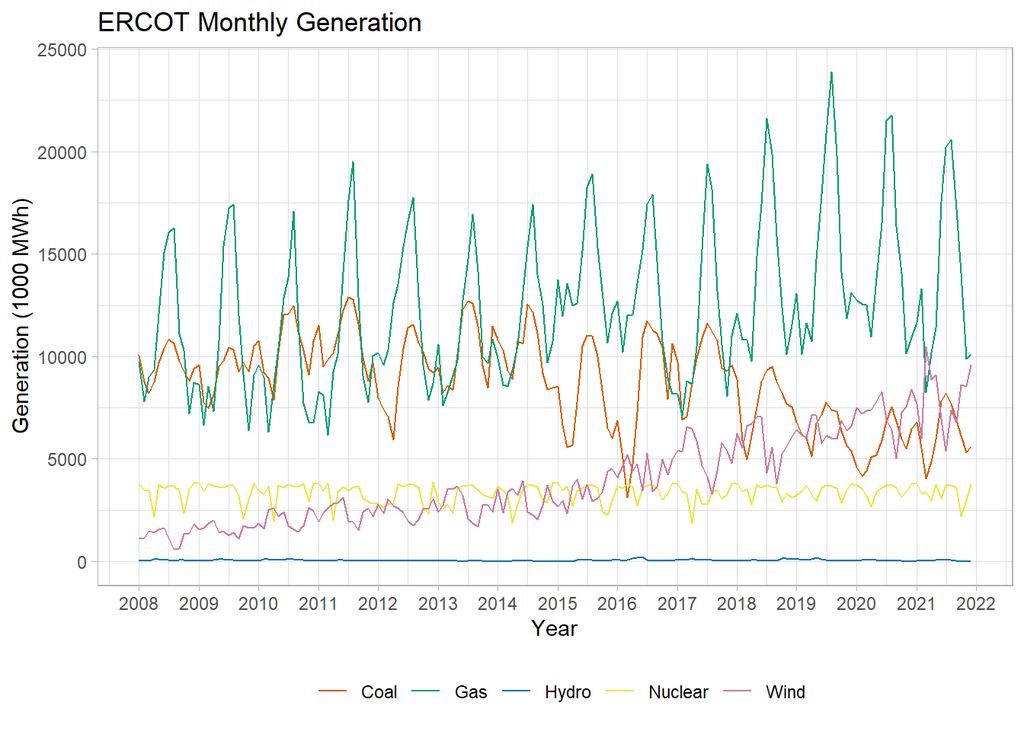

*Figure 1. ERCOT monthly generation by fuel type from 2008-2022*

**Coal:** The ACF and PACF for coal show characteristics of a seasonal auto-regressive model. The ACF has significant peaks at lag 12, 24, and 36 while the PACF showed a more sudden cut-off.

**Gas:** Gas shows a clear seasonal AR pattern with significant peaks at at lag 12, 24, and 36 and negative correlation at 6, 18, and 30. Though less distinct, the PACF does show a more sudden decline rather than a gradual decay.

**Hydro:** Hydro shows less dramatic seasonality in its ACF and clear autoregressive characteristics in the PACF with a sudden drop-off after lag one.

**Nuclear:** The ACF and PACF of Nuclear demonstrate characteristics of a non-seasonal moving average model. The ACF shows a sudden cut-off whereas the PACF shows more moderate decay.

**Wind:** Wind, like hydro, shows less dramatic seasonality in its ACF but clear autoregressive characteristics with slow decay in the ACF and a sudden drop-off after lag one in the PACF.

#### Modeling Seasonality and Forecasting Generation

This report captures results for Seasonal ARIMA, Seasonal Exponential Smoothing, and Seasonal State Space models from the forecast library package. Analysis of model performance is broken down by generation source below.

Initial modeling activity also included decomposing the time series for each generation source in order to apply a wider range of models. After deseasoning and differencing the data, the new time series were plotted along with their respective ACF and PACF. These differenced series were then modeled with auto.arima and forecasted accordingly. However, the final set of forecasting models reported here does not use these differenced time series. They instead rely only on the aforementioned models that incorporate seasonality and trend in order to maintain a more apples-to-apples comparison of model performance.

#### Coal

We first analyzed the Coal dataset. We generated and forecasted the three models (SARIMA, SES, StructTS) for the coal data.

#### Coal Forecasting

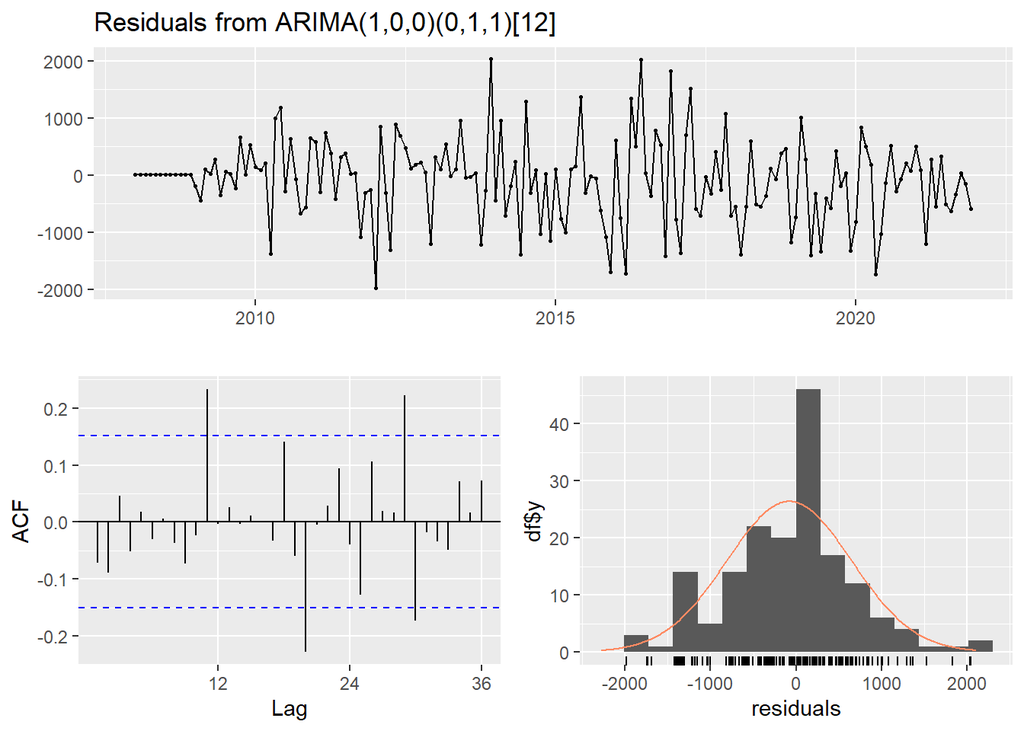

```
##
##  Ljung-Box test
##
## data:  Residuals from ARIMA(1,0,0)(0,1,1)[12]
## Q* = 31.559, df = 22, p-value = 0.08523
##
## Model df: 2.   Total lags used: 24
```

*Figure 2. Residuals for the ARIMA model for Coal.*

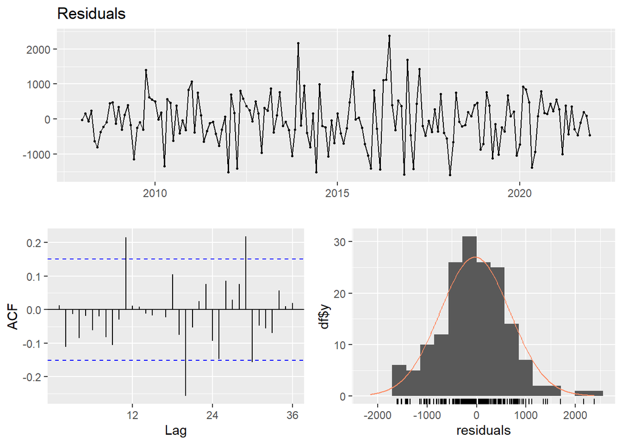

*Figure 3. Residuals for the SSES model for Coal.*

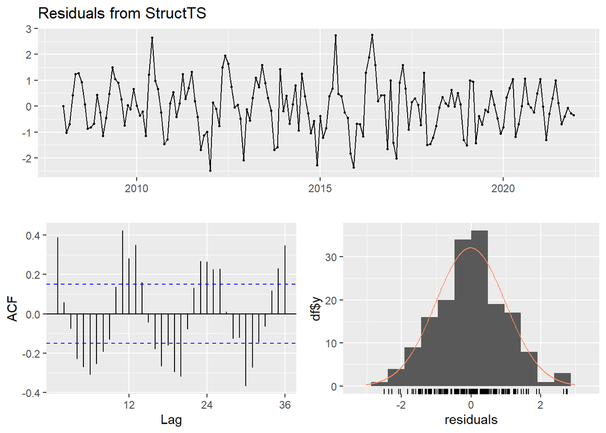

*Figure 4. Residuals for the StructTS model for Coal.*

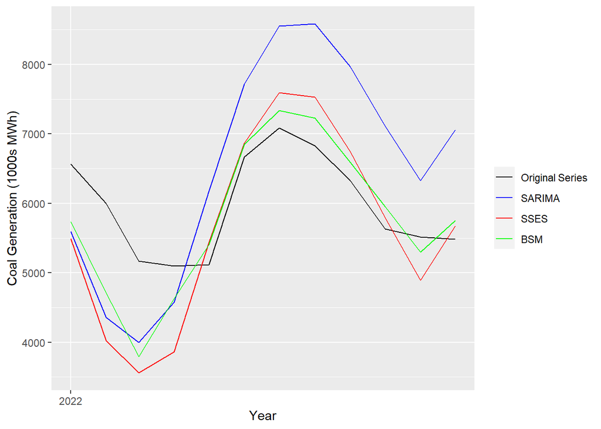

*Figure 5. 2022 coal generation forecast for each model; the original 2022 data is in black.*

#### Accuracy Scores for Coal Forecasts

We then compared the accuracy scores (ME, RMSE, MAE, MPE, and MAPE) for each of the forecasts.

*Table 2. Accuracy scores for models for Coal generation.*

```
##   coal_forecasts        ME      RMSE       MAE       MPE      MAPE
## 1         SARIMA -544.2981 1314.2261 1260.5259 -8.616635 21.099250
## 2           SSES  336.1778  943.7717  750.9580  6.381382 12.960764
## 3            BSM  184.6918  651.4245  512.6526  3.460754  8.864045
```

#### Gas

We then analyzed the natural gas dataset. We generated and forecasted the same models for the natural gas data.

#### Gas Forecasting

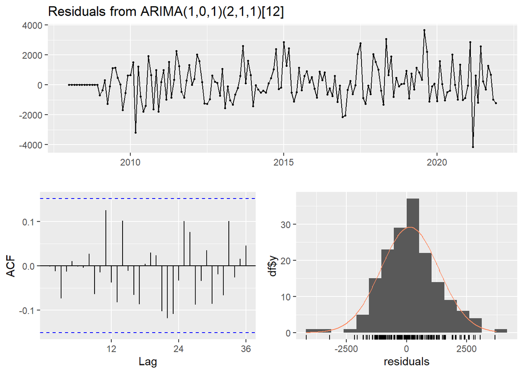

```
##
##  Ljung-Box test
##
## data:  Residuals from ARIMA(1,0,1)(2,1,1)[12]
## Q* = 18.136, df = 19, p-value = 0.5134
##
## Model df: 5.   Total lags used: 24
```

*Figure 6. Residuals for SARIMA model for Gas generation data.*

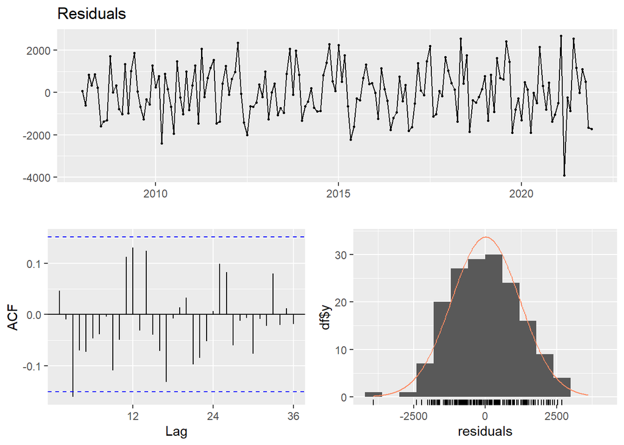

*Figure 7. Residuals for SSES model for Gas generation data.*

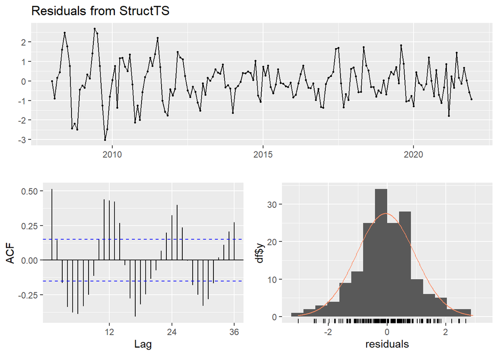

*Figure 8. Residuals for StructTS model for Gas generation data.*

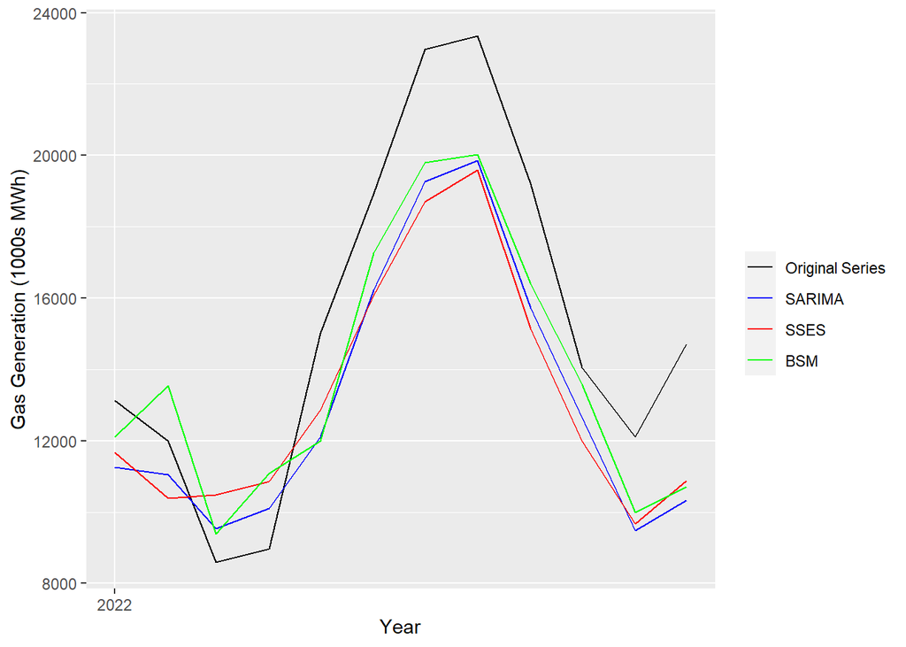

*Figure 9. 2022 gas generation forecast for each model; the original 2022 data is in black.*

#### Scores for Gas Forecasts

We compared the accuracy scores for the three forecasts to determine which model had the best forecast.

*Table 3. Accuracy scores for models for Gas generation.*

```
##   gas_forecasts       ME     RMSE      MAE       MPE     MAPE
## 1        SARIMA 2119.142 2716.245 2468.349 11.890286 15.86352
## 2          SSES 2058.310 2862.119 2687.538 10.620633 17.79333
## 3           BSM 1426.263 2416.540 2171.513  6.789384 14.43676
```

#### Hydro

Next, we analyzed the hydropower dataset. We generated and forecasted the same models as the previous datasets.

#### Hydro Forecasting

The SES model in general performs best for hydro as shown in the table of accuracy scores.

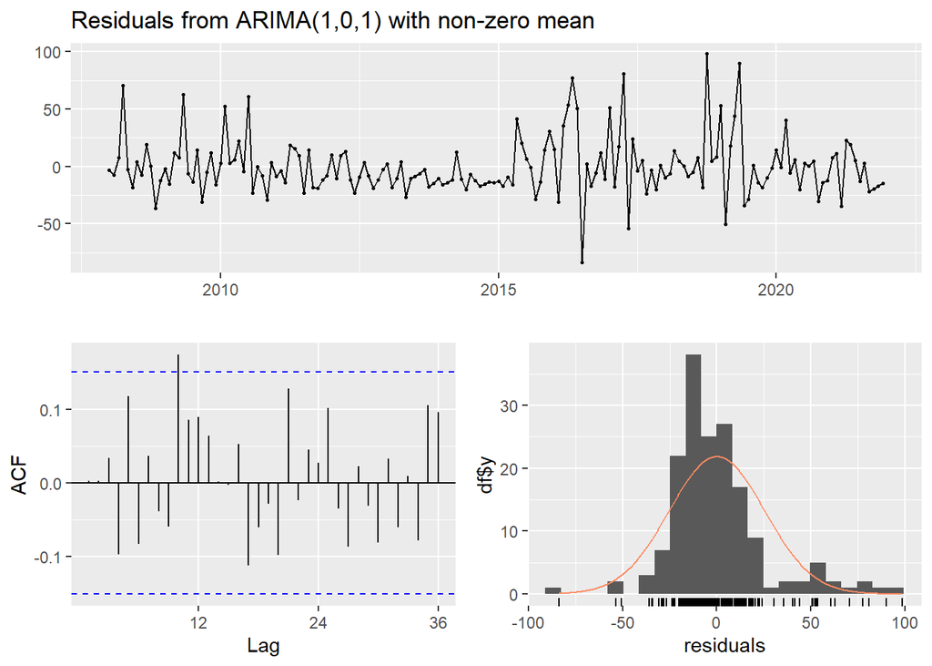

```
##
##  Ljung-Box test
##
## data:  Residuals from ARIMA(1,0,1) with non-zero mean
## Q* = 25.235, df = 22, p-value = 0.286
##
## Model df: 2.   Total lags used: 24
```

*Figure 10. Residuals for SARIMA model for hydro generation.*

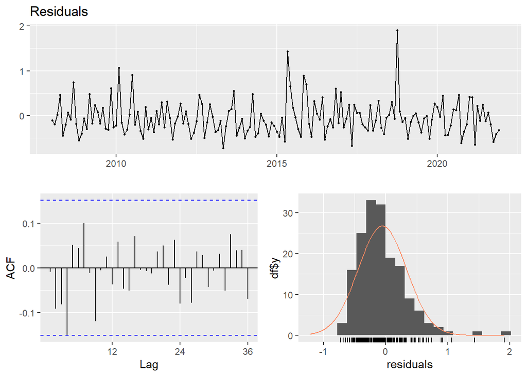

*Figure 11. Residuals for SSES model for hydro generation.*

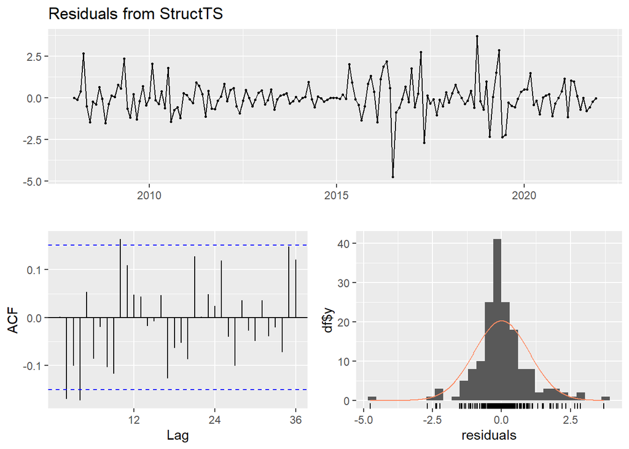

*Figure 12. Residuals for StructTS model for hydro generation.*

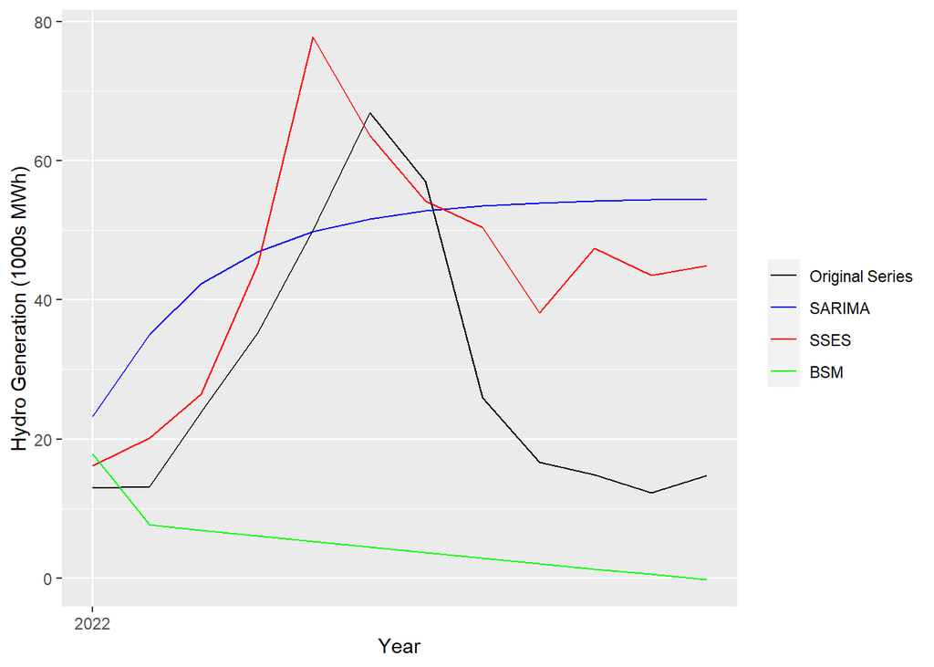

*Figure 13. 2022 hydro generation forecast for each model; the original 2022 data is in black.*

#### Scores for Hydro Forecasts

We calculated the accuracy scores to confirm which model generated the best forecast for hydro.

*Table 4. Accuracy scores for models for Hydro generation.*

```
##   hydro_forecasts        ME     RMSE      MAE        MPE      MAPE
## 1          sarima -19.06406 26.40874 22.33916 -127.89695 132.99098
## 2            SSES -15.37267 20.34528 16.38836  -88.81526  90.45466
## 3             BSM  23.79004 30.61721 24.60952   74.97965  81.30806
```

#### Nuclear

Then, we analyzed the nuclear dataset by generating and forecasting the same models as the previous datasets.

#### Nuclear Forecasting

The SARIMA model performs best for nuclear as shown in the table of accuracy scores. The residuals for all models show a similar number of significant ACF lags and distorted (ie not distinctly normal) histograms suggesting the forecasted models do not capture all of the trends.

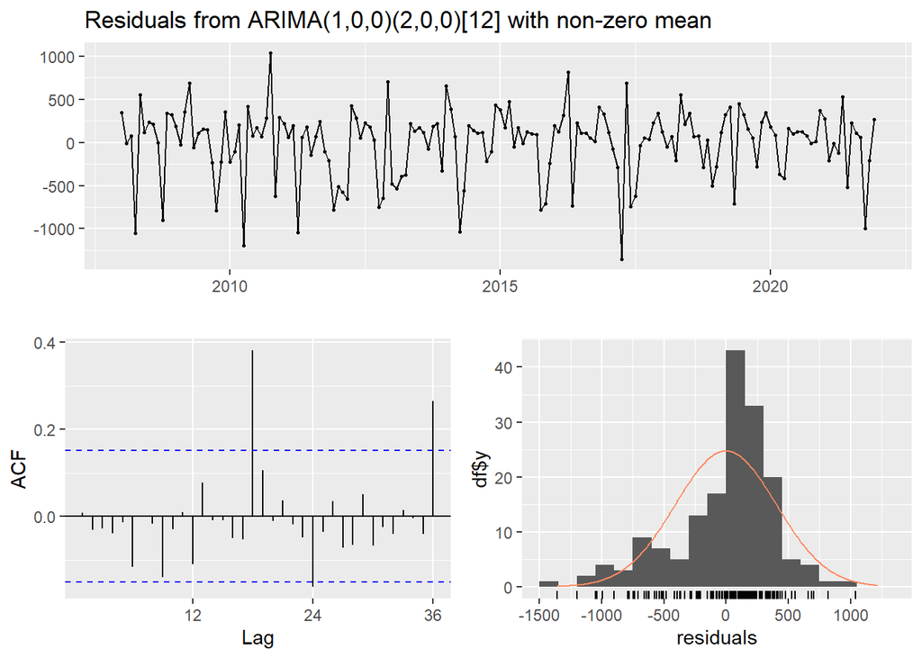

```
##
##  Ljung-Box test
##
## data:  Residuals from ARIMA(1,0,0)(2,0,0)[12] with non-zero mean
## Q* = 46.853, df = 21, p-value = 0.0009829
##
## Model df: 3.   Total lags used: 24
```

*Figure 14. Residuals for SARIMA model for nuclear generation.*

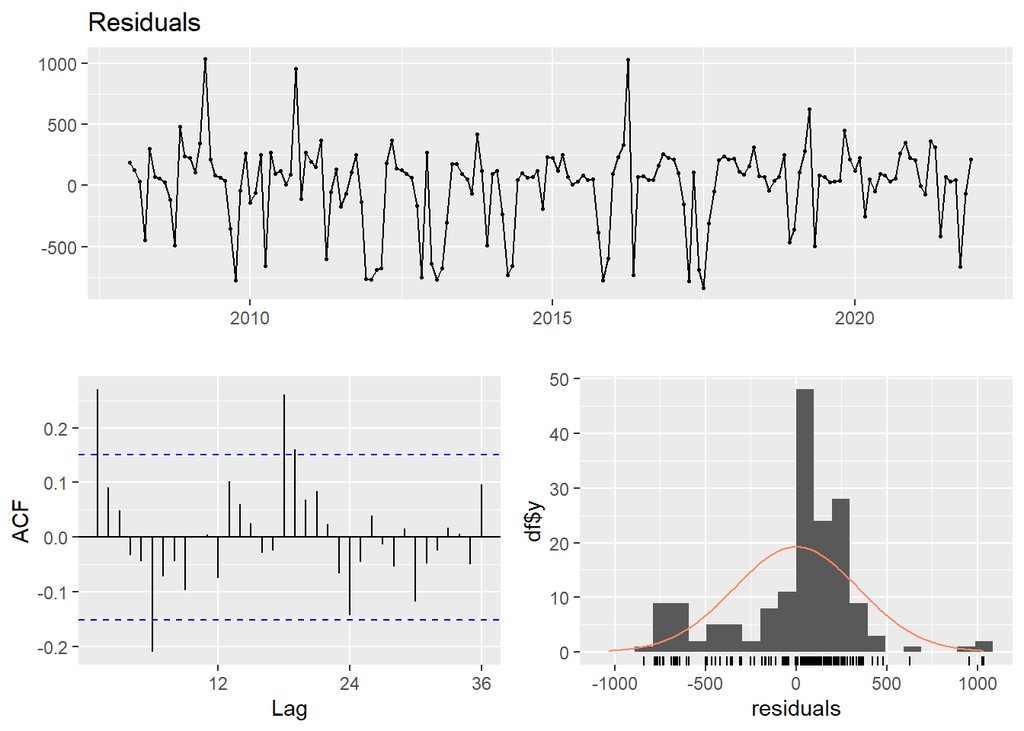

*Figure 15. Residuals for SSES model for nuclear generation.*

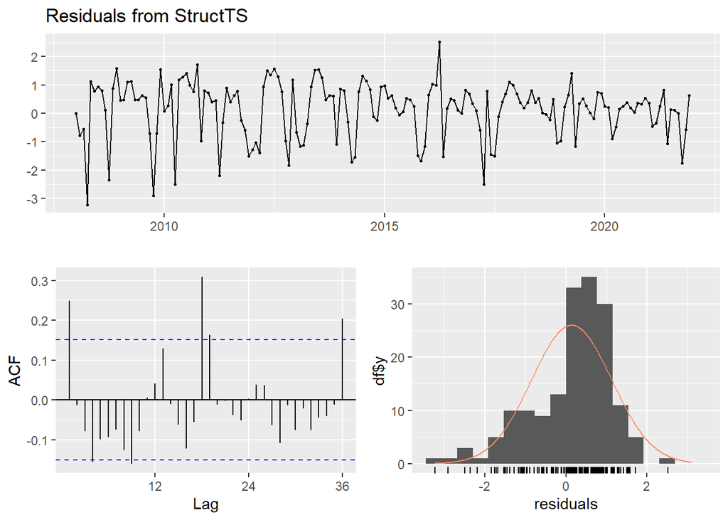

*Figure 16. Residuals for StructTS model for nuclear generation.*

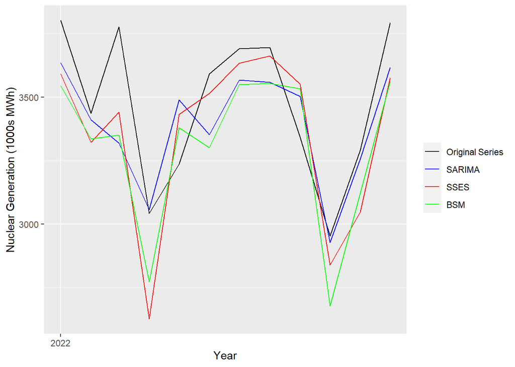

*Figure 17. 2022 nuclear generation forecast for each model; the original 2022 data is in black.*

#### Scores for Nuclear Forecasts

We checked the accuracy of each forecast to determine which model was the most accurate.

*Table 5. Accuracy scores for models for Nuclear generation.*

```
##   nuclear_forecasts        ME     RMSE      MAE      MPE     MAPE
## 1            sarima  79.84242 194.3710 151.6132 2.033984 4.230596
## 2              SSES 117.91643 215.0587 185.4679 3.393664 5.446862
## 3               BSM 164.14521 236.4025 219.8359 4.668218 6.357916
```

#### Wind

Lastly, we analyzed the wind dataset by generating and forecasting the same models as the previous datasets.

#### Wind Forecasting

The SES model in general performs best for wind as shown in the table of accuracy scores. This aligns with the report of residuals, which shows few significant lags in the ACF and normal distribution in the histogram.

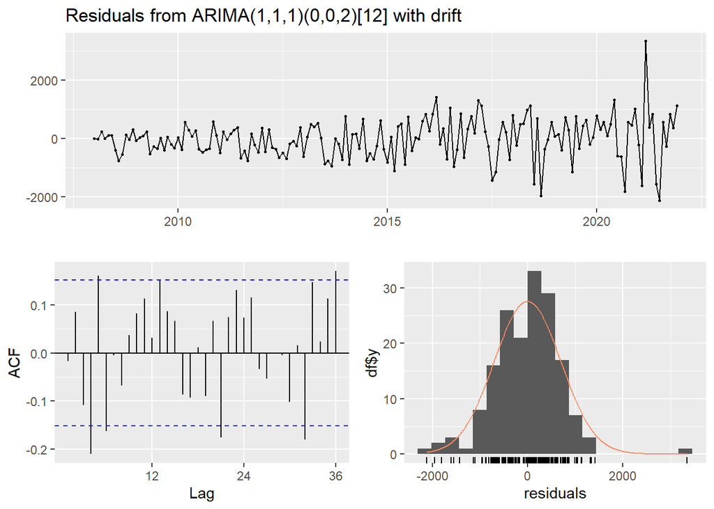

```
##
##  Ljung-Box test
##
## data:  Residuals from ARIMA(1,1,1)(0,0,2)[12] with drift
## Q* = 48.466, df = 20, p-value = 0.0003658
##
## Model df: 4.   Total lags used: 24
```

*Figure 18. Residuals for SARIMA model for wind generation.*

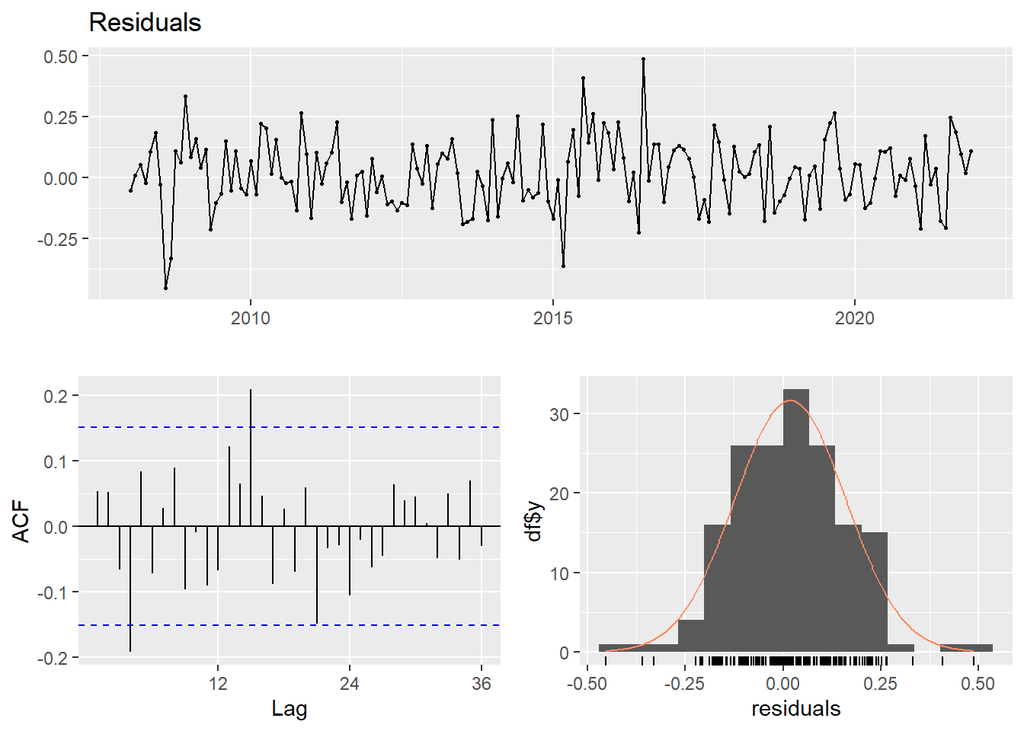

*Figure 19. Residuals for SSES model for wind generation.*

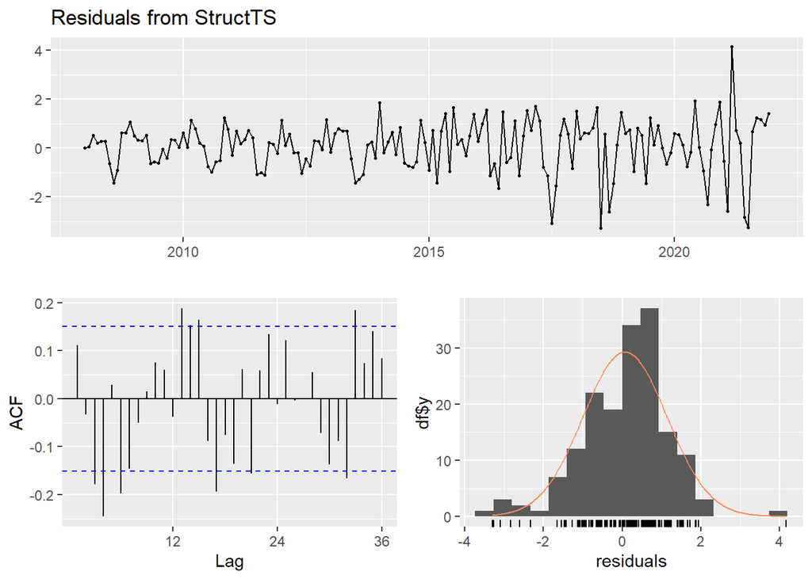

*Figure 20. Residuals for StructTS model for wind generation.*

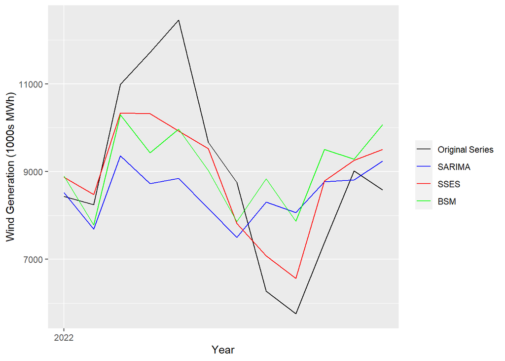

*Figure 21. 2022 wind generation forecast for each model; the original 2022 data is in black.*

#### Scores for Wind Forecasts

We calculated the accuracy scores for each model to determine the best model fit.

*Table 6. Accuracy scores for models for Wind generation.*

```
##   wind_forecasts         ME     RMSE       MAE        MPE     MAPE
## 1         sarima  439.99982 1840.853 1518.1223  0.6894469 17.34850
## 2           SSES   67.39567 1084.911  876.7277 -1.4149640  9.81835
## 3            BSM -128.98012 1616.308 1373.5710 -5.3173578 16.69650
```

#### Forecasting 2023 ERCOT generation using the best models

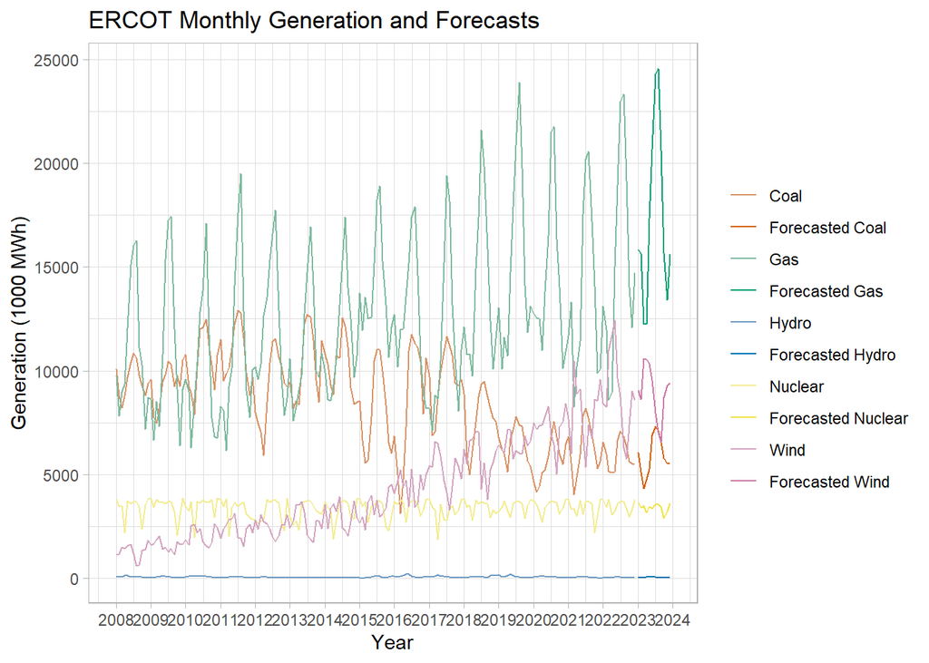

*Figure 22. ERCOT monthly generation for each fuel type and forecasts. The forecast for each fuel type are the corresponding darker shades of each color.*

#### Summary and Conclusions

Model performance appeared to correlate with level of seasonality. The State Space model performed best for coal and natural gas, both of which showed clear seasonality and autoregressive characteristics in analyzing their ACF and PACF plots. The Seasonal Exponential Smoothing model performed best for hydro and wind, both of which showed moderate seasonality and autoregressive characteristics in analyzing their ACF and PACF plots. Lastly, the SARIMA model performed best for nuclear, which did not show seasonality and illustrated moving average characteristics in its ACF and PACF plots.

The differences in which models suit which generation source also relate to the use of each fuel. Coal and Gas generation fluctuate to meet demand. These sources therefore produce far more electricity to meet summer air conditioning needs in ERCOT and a minor uptick during the winter holiday season. Hydro and wind, are less easily and non-dispatchable respectively so their generation is less tied to demand and more the operating parameters of each technology. Wind generation is in fact counter-cyclical, with relatively more produced in the winter and less in hotter, summer months. Nuclear operates as baseload power and thus demonstrates its own unique generation pattern of consistent production. Furthermore, nuclear buildout in ERCOT effectively halted prior to the start of collected data, so it does not show any trends caused by changing capacity.

#### References

[1] Gearino, D. (2023, March 9). One state generates much, much more renewable energy than any other-and it’s not California. Inside Climate News. Retrieved April 26, 2023, from https://insideclimatenews.org/news/09032023/inside-clean-energy-texas-renewables/#:~:text=No%2C%20it’s%20not%20California.,thanks%20largely%20to%20wind%20energy